# Analisis Estadistico de Datos

Grupo 05

2025-05-18

# Taller 03

**Regresion Lineal Multiple y ANOVA**  
**Maestría en Energías Renovables**  
**Escuela de Ingeniería, Ciencia y Tecnología**  
**Universidad del Rosario**  
**Integrantes:**  
Zahira Itzel González Cleves  
Diego Alejandro Mejía Montañez  
Daniel Felipe Russi Aragón  
Iván Camilo Granados Niño  
Andrés Alfonso Osorio Marulanda

```r
library(broom)
library(corrplot)
library(devtools)
library(dplyr)
library(factoextra)
library(FactoMineR)
library(forcats)
library(ggExtra)
library(GGally)
library(ggplot2)
library(kableExtra)
library(knitr)
library(lubridate)
library(MASS)
library(plotly)
library(psych)
library(purrr)
library(readr)
library(stringr)
library(tibble)
library(tidyr)
library(tidyverse)
library(usethis)
library(writexl)

#carga de datos separados con sep=;
df_EIA <- read.csv("/Users/aosoriom/Repos/MER_AEDatos/datasets/datos_taller_03.csv",sep=";",header = TRUE)
df_Turbinas <- read.csv("/Users/aosoriom/Repos/MER_AEDatos/datasets/turbinas_prod.csv",sep=",",header = TRUE)

# Extrae datos de 4 paises y con generacion solar y eolica igual a 0
datos = df_EIA %>% as_tibble() %>% # operador pipe (tuberia) encadena operaciones (~ y luego...)
             dplyr::filter(!Country %in% c('UnitedStates','China','SaudiArabia','Russia')) %>%
             dplyr::select(c("GDP_USD","Population","Solar_electricity_net_generation_BKWH","Wind_electricity_net_generation_BKWH")) %>%
             dplyr::filter(Solar_electricity_net_generation_BKWH >0 & Wind_electricity_net_generation_BKWH>0) %>%
             dplyr::mutate(GDP_USD_PER_CAPITA = GDP_USD/Population) %>%
             dplyr::select(-c('GDP_USD','Population'))

# Extrae datos de 4 paises y con generacion solar y eolica por fuera del rango (0,5]
# para solar y (0,10] para eolica).
datosRed = df_EIA %>% as_tibble() %>% # operador pipe (tuberia) encadena operaciones (~ y luego...)
             dplyr::filter(!Country %in% c('UnitedStates','China','SaudiArabia','Russia')) %>%
             dplyr::select(c("GDP_USD","Population","Solar_electricity_net_generation_BKWH","Wind_electricity_net_generation_BKWH")) %>%
             dplyr::filter(Solar_electricity_net_generation_BKWH >0 &
                             Solar_electricity_net_generation_BKWH <=5 &
                             Wind_electricity_net_generation_BKWH >0 &
                             Wind_electricity_net_generation_BKWH <=10) %>%
             dplyr::mutate(GDP_USD_PER_CAPITA = GDP_USD/Population) %>%
             dplyr::select(-c('GDP_USD','Population'))

#datos_largos <- pivot_longer(df_Turbinas, cols = starts_with("T"),
#                             names_to = "Turbina", values_to = "Produccion")
```

```r
view(datos)
```

## Modelos de Regresion Lineal

### Pregunta 1

$w_1=10$

Mediante la función `GGally::ggpairs`, grafique los diagramas de dispersión bivariados para el conjunto de datos. ¿Qué tipo de relación observa entre cada par de variables? ¿Visualmente considera que las variables Solar_electricity_net_generation_BKWH y Wind_electricity_net_generation_BKWH presentan varianza constante, (también llamada homoscedasticidad) a través de los valores de la variable GDP_USD_PER_CAPITA?

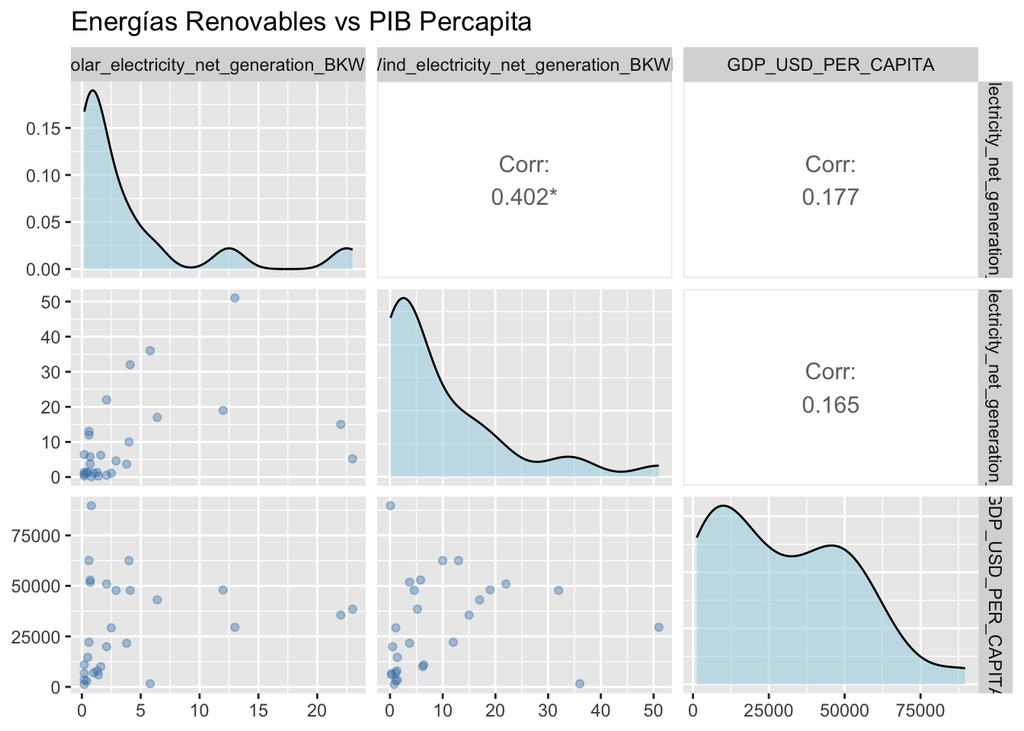

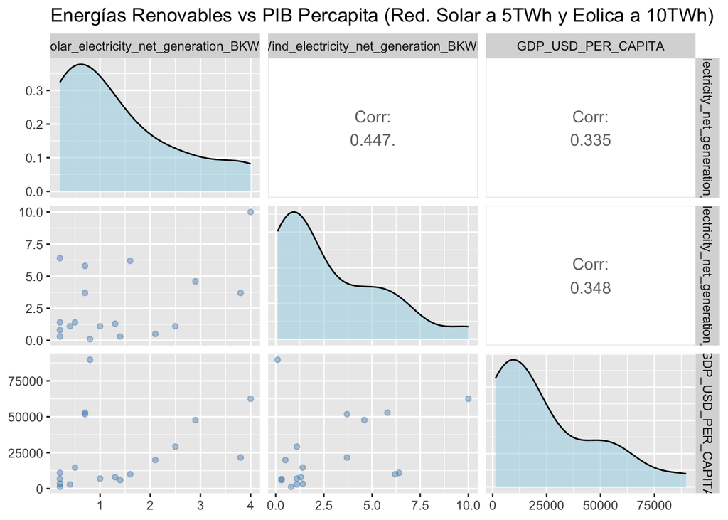

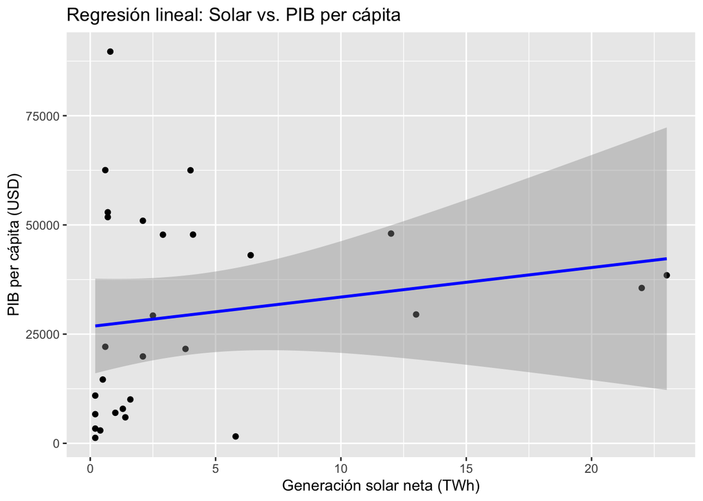

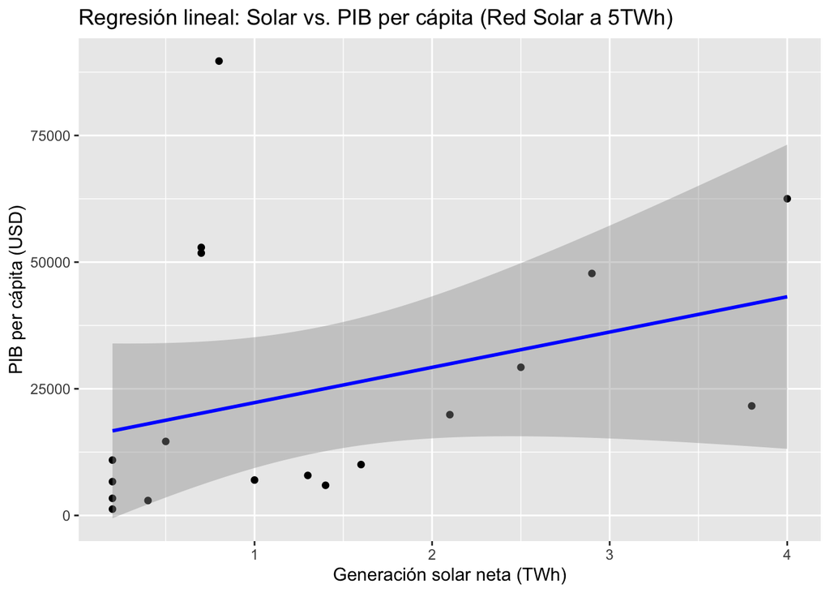

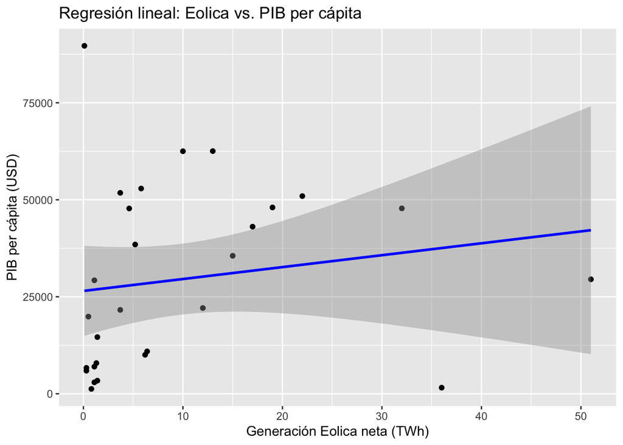

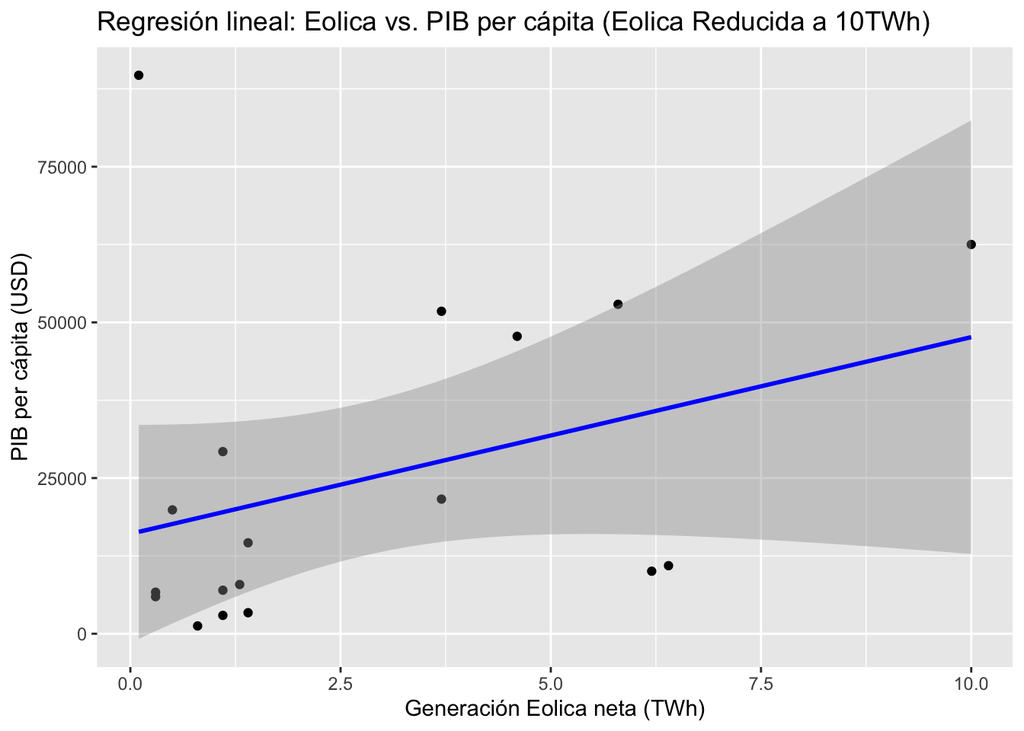

Se observa que la mayor parte de la generación solar y eólica neta se concentra en los valores menores de la gráfica, entre 0 y 5 B_kWh para solar y entre 0 y 10 B_kWh para eólica. Tomando como referencia un factor de planta del 20% y una generación neta menor a 10 B_kWh representaría capacidades instaladas de aprox. 5.7GW, lo cual represente la capacidad instalada de poco más del 70% de los paises

Por otro lado, aquellos paises con un mayor PIB percapita (> $USD\$$ 25,000) muestran rango mas amplio de generacion con fuentes renovables; de hecho las mayores generaciones se encuentran en dichos paises, asociado a que dichas economias incentivan más el uso e inversión en energias renovables.

Finalmente, al retirar los valores atípicos, los modelos de regresion líneal reducen el valor del intercepto de la energia generada en el eje Y (PIB percapita), en otras palabras, acercan las el valor al punto de mayor concetracion de datos.

### Pregunta 2

$w_2=10$

Para explicar el PIB per capita (GDP_USD_PER_CAPITA) a través de las variables en la tabla `datos` de manera simultánea, ajuste un modelo de regresión con todas las variables explicativas e interprete la salida del mismo con la ayuda de la función `summary()`. ¿Cómo interpretaría los coeficientes estimados del modelo? ¿Cuál variable parece ser más importante para explicar el GDP_USD_PER_CAPITA?

*Ayuda:*

- Recuerde utilizar el símbolo $\sim$ para establecer el modelo de regresión.
- Cuando quiera utilizar una regresión con todas las variables en el conjunto de datos, no hace falta escribir una a una, puede hacer referencia a todas mediante un punto “.”.

Call: lm(formula = Solar_electricity_net_generation_BKWH ~ GDP_USD_PER_CAPITA, data = datos)

Residuals: Min 1Q Median 3Q Max -6.0680 -2.9061 -1.8982 -0.5955 18.5080

Coefficients: Estimate Std. Error t value Pr(>|t|) (Intercept) 2.7067531 1.8918826 1.431 0.164 GDP_USD_PER_CAPITA 0.0000464 0.0000506 0.917 0.368

Residual standard error: 6.154 on 26 degrees of freedom Multiple R-squared: 0.03132, Adjusted R-squared: -0.005933 F-statistic: 0.8408 on 1 and 26 DF, p-value: 0.3676

Resumen del modelo de regresión Solar

| term | estimate | std.error | statistic | p.value |
| --- | --- | --- | --- | --- |
| (Intercept) | 2.707 | 1.892 | 1.431 | 0.164 |
| GDP_USD_PER_CAPITA | 0.000 | 0.000 | 0.917 | 0.368 |

Resumen del modelo de regresión eolico

| term | estimate | std.error | statistic | p.value |
| --- | --- | --- | --- | --- |
| (Intercept) | 7.113 | 3.877 | 1.835 | 0.078 |
| GDP_USD_PER_CAPITA | 0.000 | 0.000 | 0.851 | 0.403 |

Con base en los anteriores datos, uno de los aspectos que se visualiza es la gran diferencia en unidades, que hace que la observacion y/o los estadisticos tengan valores pequeños. En otros terminos, el analizar el PIB por ciudadano en USD versus la produccion de energia por pais en TWh implica resultados como el que la pendiente de la regresion sea 0.0000464 TWh/año por cada USD (relacion debil). Ahora si usamos como unidad de energia kWh, y no B_kWh (TWh), la pendiente de la regresion seria 46400 kWh de aumento en energia generada por cada USD de aumento en el PIB percapita, y si este valor se analiza en potencia; no en energia, indicaria que por cada USD que se incrementa el PIB percapita estaria aumentandose la capacidad instalada del pais en aprox. 30kW (Tomando de nuevo en cuenta un factor de planta del 20%).

Finalmente, un parametro F de 0.8408 y un p-value de 0.3676, sugiere que la variacion del PIB no se asocia significativamente a la variacion de la generacion de fuentes renovables.

### Pregunta 3

$w_3=15$

Según la salida de `summary()` anterior, ¿cuál es el valor del estadístico 𝐹 del modelo?. Dado su valor y el valor 𝑝 asociado del modelo, ¿son estas variables en conjunto relevantes desde el punto de vista estadístico para explicar el PIB?.

*Ayuda:*

En la función `summary()` no se obtienen los asteriscos mencionados en clase. Sin embargo, este presenta una fila de códigos de significancia: `signif. codes: pvalue < 0 - ‘***’ pvalue < 0.001 ‘**’ pvalue < 0.01 ‘*’ pvalue < 0.05 ‘.’ pvalue < 0.1 ‘ ’`

Call: lm(formula = GDP_USD_PER_CAPITA ~ ., data = datos)

Residuals: Min 1Q Median 3Q Max -34248 -18556 -6296 15218 63845

Coefficients: Estimate Std. Error t value Pr(>|t|)  
(Intercept) 25415.4 5995.9 4.239 0.000268 *** Solar_electricity_net_generation_BKWH 504.1 815.7 0.618 0.542158  
Wind_electricity_net_generation_BKWH 207.8 399.0 0.521 0.606980  
— Signif. codes: 0 ‘**’ 0.001 ’**’ 0.01 ’’ 0.05 ‘.’ 0.1 ’ ’ 1

Residual standard error: 23810 on 25 degrees of freedom Multiple R-squared: 0.04173, Adjusted R-squared: -0.03493 F-statistic: 0.5443 on 2 and 25 DF, p-value: 0.587

Resumen del modelo PIB percapita

| term | estimate | std.error | statistic | p.value |
| --- | --- | --- | --- | --- |
| (Intercept) | 25415.365 | 5995.853 | 4.239 | 0.000 |
| Solar_electricity_net_generation_BKWH | 504.130 | 815.729 | 0.618 | 0.542 |
| Wind_electricity_net_generation_BKWH | 207.838 | 398.953 | 0.521 | 0.607 |

Con estos valores se obtiene que F-statistic=0.5443 y P-value=0.587, podemos concluir que el valor estadístico de F-statics es muy bajo, lo cual indica que las variables no tienen un efecto significativo en el PIB (GDP_USD_PER_CAPITA). Por otro lado el valor p-value del modelo es 0.587, mucho mayor que 0.05, esto indica que no son significativas estadísticamente las variables tenidas en cuenta (Solar electricity net generation y Wind electricity net generation) para explicar conjuntamente el comportamiento del PIB per cápita o (GDP_USD_PER_CAPITA).

Revisando el valor P de cada variable, concluimos que la significancia de cada una (0.542158 para Solar_electricity_net_generation_BKWH y 0.606980 para Wind_electricity_net_generation_BKWH) son valores mayores a 0.05 (ningún *), confirmando de esta manera como lo indicicamos anteriormente que las variables analizadas no tienen una gran influencia o relación en el comportamiento del PIB per capita.

### Pregunta 4

$w_4=15$

A través de los gráficos asociados al modelo obtenidos con la función `plot()`, mencione respecto a los supuestos de:

Normalidad de los errores del modelo. Varianza constante. ¿Parece el modelo seguir los dos supuestos mencionados?

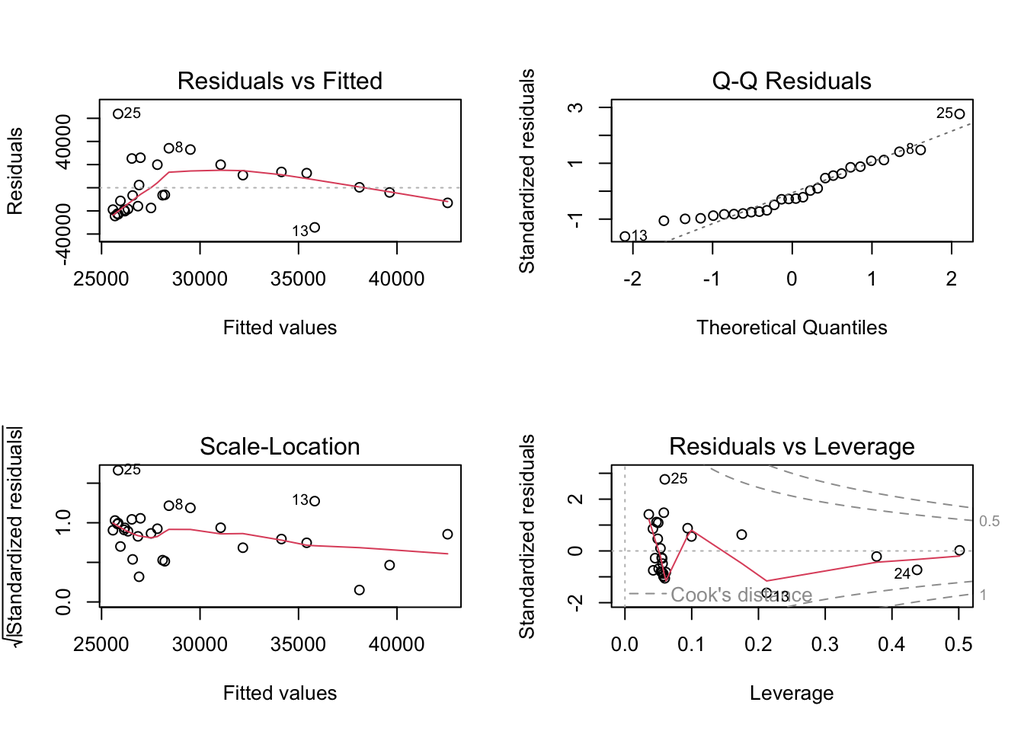

1. Normalidad de los errores del modelo: Mediante el gráfico Q-Q plot, se evidencia que existe una ligera desviación en las colas. Por lo cuál se concluye que el supuesto de normalidad no se cumple completamente.
2. Varianza constante (homocedasticidad)): Se evidencia que hay presencia de heterocedasticidad en el modelo, es decir, la varianza de los errores no es constante y cambia con el nivel del PIB predicho. Esto se concluyó a traves de:
- El gráfico Residual vs Fitted, se evidencia que los puntos no siguen la linea horizontal punteada, formando una curva y siguendo una dispersion no homogenea.
- El gráfico Scale-Location los valores de √(residuos estandarizados) disminuyen a medida que aumenta el ajuste.

Finalmente se concluye que el modelo no cumple con los supuestos de regresión.

### Pregunta 5

$w_5=20$

Estime ahora un modelo de regresión lineal múltiple, pero esta vez realice una transformación de logaritmo sobre la variable de respuesta `log(GDP_USD_PER_CAPITA)`. ¿Qué pasa ahora con el modelo cuando realizamos esta transformación? ¿Cuál modelo presenta residuales más cercanos a la distribución normal?

Call: lm(formula = log(GDP_USD_PER_CAPITA) ~ ., data = datos)

Residuals: Min 1Q Median 3Q Max -2.6985 -0.6706 0.1175 0.8788 1.8173

Coefficients: Estimate Std. Error t value Pr(>|t|)  
(Intercept) 9.547603 0.296892 32.158 <2e-16 *** Solar_electricity_net_generation_BKWH 0.048189 0.040392 1.193 0.244  
Wind_electricity_net_generation_BKWH 0.006465 0.019755 0.327 0.746  
— Signif. codes: 0 ‘**’ 0.001 ’**’ 0.01 ’’ 0.05 ‘.’ 0.1 ’ ’ 1

Residual standard error: 1.179 on 25 degrees of freedom Multiple R-squared: 0.08091, Adjusted R-squared: 0.007384 F-statistic: 1.1 on 2 and 25 DF, p-value: 0.3483

Resumen del modelo logaritmico PIB percapita

| term | estimate | std.error | statistic | p.value |
| --- | --- | --- | --- | --- |
| (Intercept) | 9.548 | 0.297 | 32.158 | 0.000 |
| Solar_electricity_net_generation_BKWH | 0.048 | 0.040 | 1.193 | 0.244 |
| Wind_electricity_net_generation_BKWH | 0.006 | 0.020 | 0.327 | 0.746 |

De los resultados anteriores se observan coeficientes positivos para la generación eólica y solar, representando que en general un aumento en estas variables está relacionado con un aumento en el logaritmo del PIB per cápita. Esto es consistente con la regresión sin el logaritmo.

Sin embargo, el valor P de la regresión es de 0.34, y el valor P para la generación solar y eólica se encuentra en 0.244 y 0.746, respectivamente. Como los tres valores P presentan valores altos, se concluye que estas variables no explican al logaritmo del PIB per cápita de forma lineal.

A esto se le suma que el R2 tiene también un valor bajo, de 0.08.

Para verificar cómo se comportan los residuales de esta nueva regresión se grafica lo siguiente:

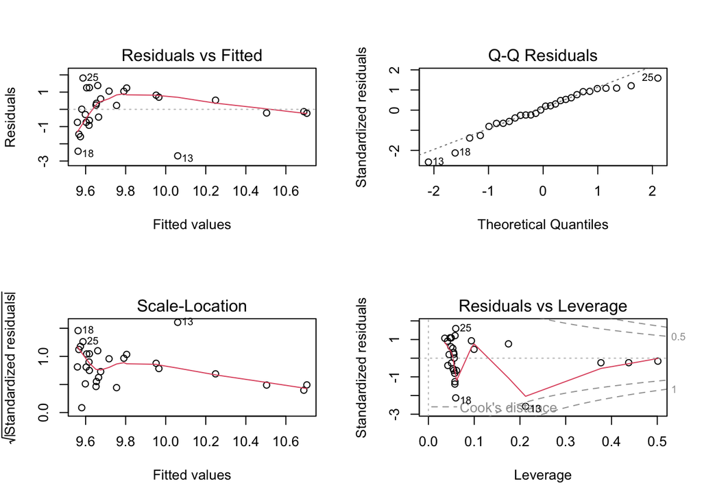

De la imagen anterior, de la gráfica Q-Q se observa que los residuales siguen una línea recta de mejor manera que en el caso de la regresión sin el logaritmo, indicando que los residuales se acercan más a una distribución normal. No obstante, hay algunos puntos que se salen de esa línea recta.

Una observación interesante es entonces que el hecho de aplicar el logaritmo al PIB per cápita no afectó la regresión en cuanto a que se mantiene la conclusión de que no hay una relación lineal entre las variables, pero sí mejoró el comportamiento estadístico de los residuales.

A pesar de la distribución normal de los residuales mostró una mejora, en las gráficas Residuals vs Fitted y Scale-Location se evidencia que los puntos se encuentran concentrados hacia la izquierda y hay algunos puntos que siguen una línea diagonal. Por lo tanto, la varianza de los errores continúa siendo no constante, es decir, no hay homocedasticidad.

## ANOVA

En el conjunto de datos `turbinas_prod.csv` cuenta con la producción mensual promedio de 5 turbinas eólicas ubicadas en la Guajira. Esta información se tiene por un total de 12 meses para cada turbina y la medición esta dada en MWh. Se busca determinar si existen diferencias significativas entre la producción promedio de energía de las turbinas.

### Pregunta 6

$w_6=5$

Realice el boxplot de producción para las diferentes turbinas y determine visualmente si observa diferencias en la producción de energía de las 5 turbinas. ¿Parece haber varianza constante en las observaciones de las turbinas?

*Ayuda:*

Puede resultarle conveniente usar la función `pivot_longer`, con la cual, puede cambiar el formato ancho al largo de la base de datos, Basta con: `pivot_longer(datos,cols=columnas_de_base,names_to='Nombre_nueva_col1',values_to='Nombre_nueva_col2')`

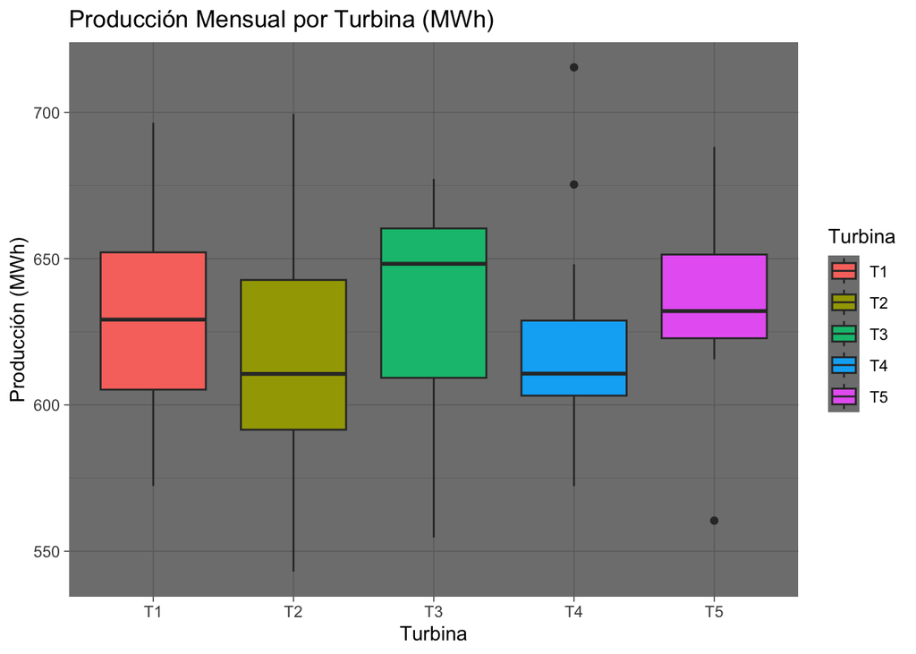

### Pregunta 7

$w_7=5$

Ajuste un modelo de regresión lineal simple para explicar la producción usando la variable de turbina ¿A qué es igual el R2 del modelo ajustado? ¿Cómo interpreta los parámetros estimados del modelo? ¿Cuál es la categoría de referencia pra el modelo ajustado?

Call: lm(formula = Produccion ~ Turbina, data = datos_largos)

Residuals: Min 1Q Median 3Q Max -77.95 -20.36 -3.83 26.50 93.77

Coefficients: Estimate Std. Error t value Pr(>|t|)  
(Intercept) 633.0908 11.1158 56.954 <2e-16 *** TurbinaT2 -16.9046 15.7201 -1.075 0.287  
TurbinaT3 -0.4173 15.7201 -0.027 0.979  
TurbinaT4 -11.4873 15.7201 -0.731 0.468  
TurbinaT5 2.0254 15.7201 0.129 0.898  
— Signif. codes: 0 ‘**’ 0.001 ’**’ 0.01 ’’ 0.05 ‘.’ 0.1 ’ ’ 1

Residual standard error: 38.51 on 55 degrees of freedom Multiple R-squared: 0.03937, Adjusted R-squared: -0.03049 F-statistic: 0.5635 on 4 and 55 DF, p-value: 0.6901

Resumen del modelo Produccion Turbina

| term | estimate | std.error | statistic | p.value |
| --- | --- | --- | --- | --- |
| (Intercept) | 633.091 | 11.116 | 56.954 | 0.000 |
| TurbinaT2 | -16.905 | 15.720 | -1.075 | 0.287 |
| TurbinaT3 | -0.417 | 15.720 | -0.027 | 0.979 |
| TurbinaT4 | -11.487 | 15.720 | -0.731 | 0.468 |
| TurbinaT5 | 2.025 | 15.720 | 0.129 | 0.898 |

El $R^2$ ajustado es igual a -0.03049, lo que indica que el modelo no mejora la explicación sobre la media.

Los coeficientes estiman la diferencia promedio en producción respecto a la turbina de referencia T1. En este caso la producción promedio de la T1 es igual a 633.0908 y por ejemplo en promedio la turbina T5 produce 2.0254 más que la T1.

La categoría de referencia es la Turbina T1, ya que no aparece explícitamente en los coeficientes del modelo y el valor de estimación estándar equivale al promedio de su producción igual a 633.0908.

### Pregunta 8

$w_8=5$

Mediante los parámetros del modelo ajustado, ¿cuál es la producción promedio de la turbina 4? verifique el resultado calculando el promedio simple para las observaciones de la turbina en cuestión.

[1] 621.6035

Call: lm(formula = Produccion ~ Turbina, data = datos_largos)

Residuals: Min 1Q Median 3Q Max -77.95 -20.36 -3.83 26.50 93.77

Coefficients: Estimate Std. Error t value Pr(>|t|)  
(Intercept) 633.0908 11.1158 56.954 <2e-16 *** TurbinaT2 -16.9046 15.7201 -1.075 0.287  
TurbinaT3 -0.4173 15.7201 -0.027 0.979  
TurbinaT4 -11.4873 15.7201 -0.731 0.468  
TurbinaT5 2.0254 15.7201 0.129 0.898  
— Signif. codes: 0 ‘**’ 0.001 ’**’ 0.01 ’’ 0.05 ‘.’ 0.1 ’ ’ 1

Residual standard error: 38.51 on 55 degrees of freedom Multiple R-squared: 0.03937, Adjusted R-squared: -0.03049 F-statistic: 0.5635 on 4 and 55 DF, p-value: 0.6901

Resumen del modelo Produccion Promedio Turbina 4

| term | estimate | std.error | statistic | p.value |
| --- | --- | --- | --- | --- |
| (Intercept) | 633.091 | 11.116 | 56.954 | 0.000 |
| TurbinaT2 | -16.905 | 15.720 | -1.075 | 0.287 |
| TurbinaT3 | -0.417 | 15.720 | -0.027 | 0.979 |
| TurbinaT4 | -11.487 | 15.720 | -0.731 | 0.468 |
| TurbinaT5 | 2.025 | 15.720 | 0.129 | 0.898 |

Como se observa, el promedio calculado por los 2 métodos es igual.

### Pregunta 9

$w_9=5$

Determine mediante una prueba estadística apropiada si existen diferencias significativas entre la producción promedio de energía de las turbinas. ¿A qué es igual el valor del estadístico $𝐹$ $F$ en la prueba de hipótesis correspondiente?

```
        Df Sum Sq Mean Sq F value Pr(>F)
```

Turbina 4 3342 835.6 0.564 0.69 Residuals 55 81551 1482.7

Resumen del modelo ANOVA Produccion Turbina

| term | df | sumsq | meansq | statistic | p.value |
| --- | --- | --- | --- | --- | --- |
| Turbina | 4 | 3342.295 | 835.574 | 0.564 | 0.69 |
| Residuals | 55 | 81550.584 | 1482.738 | NA | NA |

Teniendo en cuenta que el valor de F values es bajo (0.564), lo cual indica que las diferencias entre grupos no son significativamente mayores que la variabilidad interna de cada grupo, y que el p-valor = 0.69; se concluye que, no hay evidencia estadísticamente significativa de que las turbinas tengan diferentes producciones promedio.

### Pregunta 10

$w_10=10$

Encuentre los residuales del modelo ajustado y con estos realice una estimación kernel de la densidad (como lo vimos en la primera sesión de clase) junto a un histograma. ¿Encuentra una distribución conocida para los residuales del modelo?

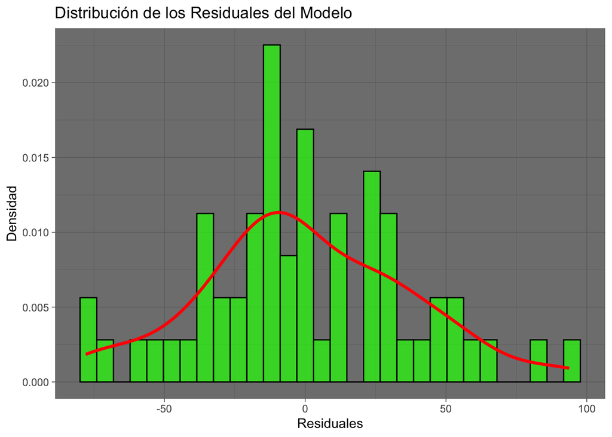

- La estimación de kernel que corresponde a la curva de color rojo presenta una forma similar a una campana con un ligero sesgo a la derecha, esto indica que se tiene cercanía a la distribución normal
- La ligera asimetría que muestra la curva de kernel también indica que este sesgo tiene una distribución positiva.
- En cuanto al histograma, se observan 2 picos significativos, el primero cercano a cero que de acuerdo a lo visto en clases es esperado por el ajuste del modelo. El segundo pico está situado en la mitad del intervalo 0-50, indicando que la distribución de los datos no es uniforme y presenta saltos importantes.
- Finalmente, no se observan sesgos importantes más allá del que se marca levemente a la derecha. Lo anterior indica baja presencia de valores atípicos.

En general, con los resultados obtenidos hasta aquí no se observan valores extremos con los que no se acepten la normalidad de los errores.

# Referencias

1. [Introduction to R markdown](https://rmarkdown.rstudio.com/articles_intro.html)
2. [MarkDown Guide - Basic Syntax](https://www.markdownguide.org/basic-syntax/)
3. [Data Visualization CheatSheet](https://github.com/rstudio/cheatsheets/blob/main/data-visualization.pdf)
4. [Repositorio del Taller en Github](https://github.com/aosoriom7/MER_AED_2025I)
5. [Pagina web del taller en Gihub Pages](https://aosoriom7.github.io/MER_AED_2025I/scripts/T03_AEDatos.html)
6. [Solar Power by Country](https://en.wikipedia.org/wiki/Solar_power_by_country)